# Cellchat for analyzing intercellular communication

Suoqin Jin

28 April, 2025

Identifying intercellular (cell-cell) interactions has remained elusive to many fields of biology. The emergence of single cell RNA sequencing technologies has presented us with a tremendous amount of data and a potentially infinite amount of receptor-ligand interactions.

There are several different packages/algorithms that attempt to infer intercellular interactions from sc/snRNASeq data. These packages were nicely review and combined in a Nature Communications paper https://pmc.ncbi.nlm.nih.gov/articles/PMC9184522/

[figure not shown]

There are pros and cons to each fo the different algorithms. The most commonly used are CellPhoneDB and CellChat. I like CellChat because of its numerous visualization methods that are great for papers and presentations.

Today I’ll work through a single dataset using CellChat. I will go through some of CellChat’s diverse functionalities by applying it to a mouse single nuclear dataset.

CellChat requires gene expression data of cells as the user input and models the probability of cell-cell communication by integrating gene expression with prior knowledge of the interactions between signaling ligands, receptors and their cofactors.

[figure not shown]

Upon infering the intercellular communication network, CellChat provides functionality for further data exploration, analysis, and visualization.

## Load the required libraries

```r
library(BiocNeighbors)
library(CellChat)
library(patchwork)
library(presto)
library(here)
library(Seurat)
options(stringsAsFactors = FALSE)
```

# Part I: Data input & processing and initialization of CellChat object

CellChat requires two user-defined inputs: one is the gene expression data of cells, and the other is either user assigned cell labels (i.e., label-based mode) or a low-dimensional representation of the single-cell data (i.e., label-free mode). In this case, we will use labeled kidney cells, from KGB and JWN’s publication in Physiological Genomics (https://journals.physiology.org/doi/prev/20250221-aop/abs/10.1152/physiolgenomics.00161.2024).

[figure not shown]

This is a mouse single nuclear RNA seq dataset. Mice underwent cardiac arrest then resuscitation (a global ischemia model) or sham procedure.

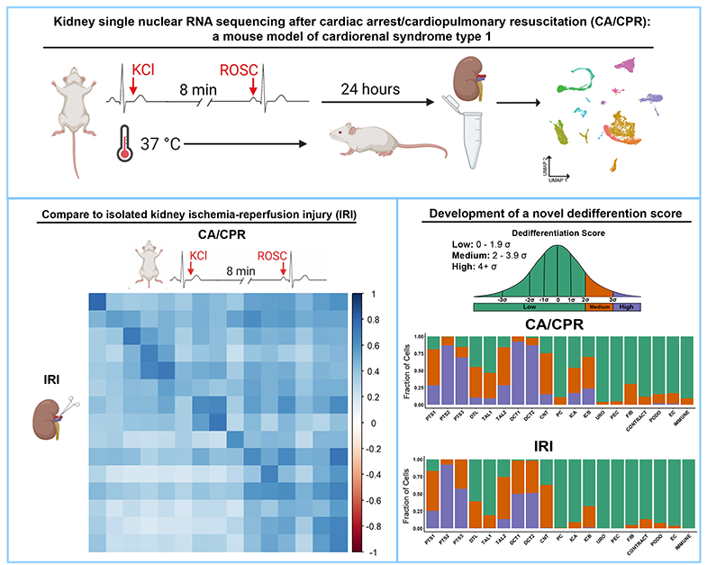

## Load data

*For the gene expression data matrix*, genes should be in rows with rownames and cells in columns with colnames. Normalized data (e.g., library-size normalization and then log-transformed with a pseudocount of 1) is required as input for CellChat analysis.

If the user provides count data, CellChat provides a `normalizeData` function to account for library size and then do log-transformed. *For the cell group information*, a dataframe with rownames is required as input for CellChat.

```r
# We will start by loading the .rds file that Jonathan generated
CACPR_integrated <- readRDS(here("Week 4 CellChat", "data", "CACPR_integrated.rds"))
CACPR_integrated@meta.data
```

[output not shown]

[output cut: 26266 more lines]

[output not shown]